# PT_P2_Mijares_Anthony (1)

## Data Acquisition

```python
import matplotlib.pyplot as plt
from sklearn.datasets import load_iris

# Load data
data = load_iris()

# Separate features and target
X = data.data
y = data.target
```

## Preprocessing

```python
# Splitting the data for training and testing
from sklearn.model_selection import train_test_split
X_Train, X_Test, y_Train, y_Test = train_test_split(X, y, test_size=0.2, random_state=0)
```

## Model Building

```python
# Create a KNeighborsClassifier object
from sklearn.neighbors import KNeighborsClassifier
knn = KNeighborsClassifier(n_neighbors= 5)

# Train the model using the training data
knn.fit(X_Train, y_Train)
```

```
KNeighborsClassifier()
```

## Prediction

```python
# Use the model to predict the test set
predictions = knn.predict(X_Test)
```

## Evaluation

```python
# Check Accuracy
from sklearn.metrics import accuracy_score
accuracy = accuracy_score(y_Test, predictions)
print("Accuracy:", accuracy)
print()

# Evaluate model performance
from sklearn.metrics import classification_report
print("classification report")
print(classification_report(y_Test, predictions))
```

```
Accuracy: 0.9666666666666667

classification report
              precision    recall  f1-score   support

           0       1.00      1.00      1.00        11
           1       1.00      0.92      0.96        13
           2       0.86      1.00      0.92         6

    accuracy                           0.97        30
   macro avg       0.95      0.97      0.96        30
weighted avg       0.97      0.97      0.97        30
```

## Visualization

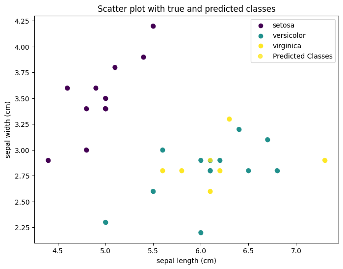

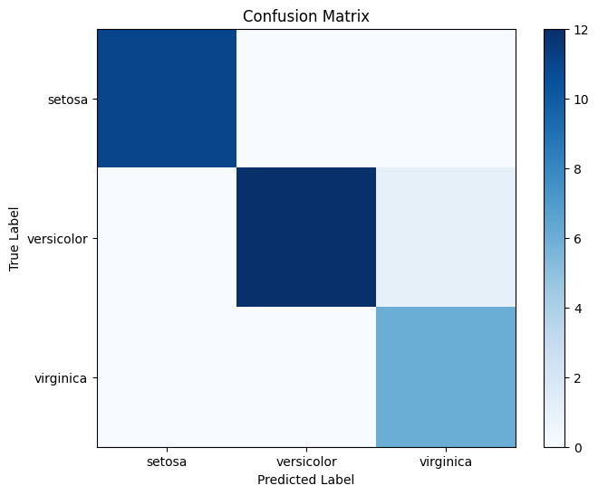

```python
# Visualization of the Scatter plot with predicted classes
import matplotlib.pyplot as plt
plt.figure(figsize=(8,6))

# Define colors for true classes (mimicking viridis for first three classes visually)
colors = ['#440154', '#21908d', '#fde725'] # Example colors from viridis cmap for distinctness

for i in range(3):
  plt.scatter(X_Test[:,0][y_Test == i], X_Test[:,1][y_Test ==i], c=colors[i], label=data.target_names[i])

# Plot the predicted classes with original viridis colormap, removing marker and size
plt.scatter(X_Test[:,0],X_Test[:,1], c=predictions, cmap='viridis', alpha=0.8, label='Predicted Classes')

plt.xlabel(data.feature_names[0])
plt.ylabel(data.feature_names[1])
plt.title("Scatter plot with true and predicted classes")
plt.legend()
plt.show()
print()

# Making a confusion matrix
from sklearn.metrics import confusion_matrix
cm = confusion_matrix(y_Test, predictions)

# Confusion matrix visualization
plt.figure(figsize=(8, 6))
plt.imshow(cm, cmap='Blues' )
plt.colorbar()
plt.title("Confusion Matrix")
plt.xlabel("Predicted Label")
plt.ylabel("True Label")
plt.xticks(ticks=range(3), labels=data.target_names)
plt.yticks(ticks=range(3), labels=data.target_names)
plt.show()
```

## Output Analysis and Experiment

**Analyze and examine the code and output by answering the following questions:**

**• What is the purpose of this program? What is it trying to predict?**

**Answer:** Based on my own take, the program is designed to showcase how the kNN behaves by specifically to predict the specific species the separated from the dataset to be used for testing which is specifically 30 out of 150 (20%) and provide an evaluation on how accurate it is, and visualize it through Scatter plot and Confusion Matrix

• How does the n_neighbors parameter in the KNN model influence its predictions? Experiment with different values and observe the change in accuracy.

**Answer:** According to our previous discusing the k or the n_neighbor parameter plays a big role in deciding which category an unknown subject belong to, so by ensuring that the k parameter is on it's so called sweet-spot you can ensure that the prediction will be accurate enough and or perhaps not prone to overfitting. On this scenario, making the value of the k parameter higher can reduce the accuracy and on the other hand if you change it to 4 it will output 100% percent but lowering it to 3 can provide the same accuracy as 5, which is 96.67%.

• What is the purpose of the confusion matrix? What does it tell you about the types of errors the model makes? Are there any patterns in the misclassified instances?

**Answer:** It's main purpose is to provide a visual representation of the judgement or simply tallies up on how the model performs whether how many predictions was mistakenly predicted correct and vice versa. By looking at the confusion matrix the Setosa is only white on its own column and its own row, while in contrast both has a feint light blue beside versicolor and on the or virginica indicating that there are errors that happened which is evident on the classification report. Pattern indicates that versicolor and virginia are too similar for the model to accurately distinguish perfectly.